[figure not shown]

# Quora

Quora is a community question and answer website. In one of our experiments, we investigated whether performing Google web searches that are modeled after the web search behavior of individuals with a psychiatric disorder would result in advertisements and content on Quora different from a control not performing any web searches.

# Methodology

- **Stage 1:** In stage 1, we created six different Quora accounts: 2 reflecting a subject with Mood Disorder, 2 for Schizophrenia, and 2 as the Control (that is, subject with no psychiatric illness).
- **Stage 2:** In stage 2, while logged into the corresponding Google accounts, we performed Google searches every 1 – 2 days. These Google searches were modeled after the internet search behavior of individuals with a mood disorder or schizophrenia. Web searches for profiles within a group were identical and performed in the same order each day, and the top web result on each search was clicked into. None of the sites clicked into belonged to Quora itself. All our experiments were done using profiles with Google “sync” on, and we did not opt out of cookies and had neither ad blockers nor strict privacy settings enabled to prevent targeted advertising. We tried to control as many factors as possible; however, there are many complex factors in play when it comes to targeted advertising.
- **Stage 3:** Quora claims that they offer “contextual” and “behavioral” targeting for advertisers, and we wanted to see what exactly they mean by this. After each web browsing session, we went to Quora’s homepage, and collected all the advertisements from their site’s newsfeed.
- **Stage 4:** At the end of our experiment, we downloaded and parsed all the Quora Digest emails each account received over the course of the experiment. Quora Digest is a daily email sent by Quora that contains a set of personalized, recommended questions.
- **Stage 5:** All data was analyzed using R programming.

# Web Search Methodology

What DO individuals with mood disorders or schizophrenia search for online? To find out, we consulted literature on prior research that studied the most frequently used language and topics of online searches by individuals with a mood disorder or schizophrenia. Once we had a list of commonly used language and frequently searched topics, we needed to generate our simulated web searches for each profile. To accomplish this, we used something called a grammar to generate our search strings.

# Results

## Quora Site Advertisements

### Descriptive Statistics

A chi-square test of independence shows that there is no significant difference in the distribution of Quora site advertisement topics or Quora sponsors between the three groups (P>.05).

|  | control (N=35) | mood disorder (N=64) | schizophrenia (N=63) | P-value |
| --- | --- | --- | --- | --- |
| Quora Site Ad Type |  |  |  |  |
| Games Apps & Quizzes | 8.00 (22.9%) | 11.0 (17.2%) | 14.0 (22.2%) | 0.718 |
| Healthcare | 3.00 (8.6%) | 9.00 (14.1%) | 11.0 (17.5%) |  |
| News | 6.00 (17.1%) | 8.00 (12.5%) | 7.00 (11.1%) |  |
| Political | 3.00 (8.6%) | 3.00 (4.7%) | 1.00 (1.6%) |  |
| Selling Product(s) | 15.0 (42.9%) | 33.0 (51.6%) | 30.0 (47.6%) |  |
| Quora Site Ad Sponsors |  |  |  |  |
| Atlassian | 1.00 (2.9%) | 0 (0%) | 3.00 (4.8%) | 0.668 |
| CapitalOne Shopping | 7.00 (20.0%) | 14.0 (21.9%) | 16.0 (25.4%) |  |
| Forge of Empires | 2.00 (5.7%) | 2.00 (3.1%) | 6.00 (9.5%) |  |
| Gazillions | 1.00 (2.9%) | 3.00 (4.7%) | 2.00 (3.2%) |  |
| Gundry MD | 1.00 (2.9%) | 4.00 (6.3%) | 3.00 (4.8%) |  |
| Local Solar Power Programs | 2.00 (5.7%) | 2.00 (3.1%) | 2.00 (3.2%) |  |
| Magellan Times | 1.00 (2.9%) | 0 (0%) | 0 (0%) |  |
| ManageEngine | 1.00 (2.9%) | 0 (0%) | 0 (0%) |  |
| Shopify | 1.00 (2.9%) | 2.00 (3.1%) | 3.00 (4.8%) |  |
| Square Online | 1.00 (2.9%) | 0 (0%) | 1.00 (1.6%) |  |
| Stansberry Research | 3.00 (8.6%) | 3.00 (4.7%) | 1.00 (1.6%) |  |
| System1 | 2.00 (5.7%) | 3.00 (4.7%) | 4.00 (6.3%) |  |
| The Penny Hoarder | 1.00 (2.9%) | 0 (0%) | 0 (0%) |  |
| TruthFinder | 2.00 (5.7%) | 10.0 (15.6%) | 4.00 (6.3%) |  |
| Upbeat News | 4.00 (11.4%) | 7.00 (10.9%) | 4.00 (6.3%) |  |
| Worldlifestyle | 5.00 (14.3%) | 6.00 (9.4%) | 6.00 (9.5%) |  |
| Avnet | 0 (0%) | 1.00 (1.6%) | 0 (0%) |  |
| BairesDev | 0 (0%) | 1.00 (1.6%) | 0 (0%) |  |
| Beverly Hills MD (BHMD) | 0 (0%) | 2.00 (3.1%) | 2.00 (3.2%) |  |
| Maternity Week | 0 (0%) | 1.00 (1.6%) | 0 (0%) |  |
| Network Solutions | 0 (0%) | 1.00 (1.6%) | 0 (0%) |  |
| The Motley Fool | 0 (0%) | 1.00 (1.6%) | 0 (0%) |  |
| Wesley Financial Group, LLC | 0 (0%) | 1.00 (1.6%) | 0 (0%) |  |
| Best Gadget Advice | 0 (0%) | 0 (0%) | 2.00 (3.2%) |  |
| ContentFly | 0 (0%) | 0 (0%) | 1.00 (1.6%) |  |
| Eden Health | 0 (0%) | 0 (0%) | 2.00 (3.2%) |  |
| History Daily | 0 (0%) | 0 (0%) | 1.00 (1.6%) |  |

### Proportion of each type of Quora advertisement type conditioned on group

Below is a stacked bar chart of the proportion of each advertisement type of Quora newsfeed conditioned on the profile group. There does not appear to be an association in the distribution of ad types between the three different groups.

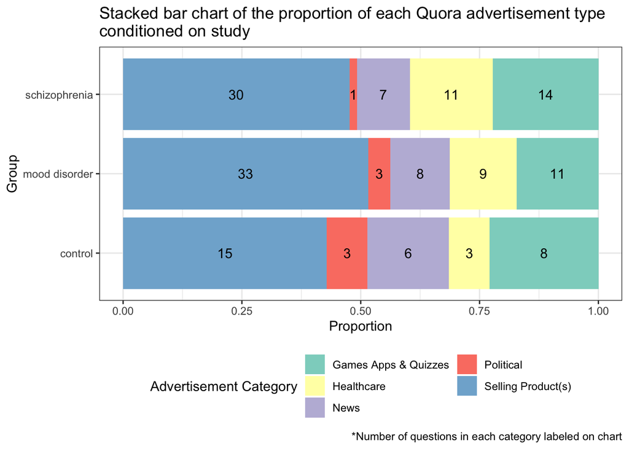

## Quora Digest Emails

### Descriptive Statistics

A chi-square test of independence shows that there is a significant difference in the distribution of Quora Digest topics between the three groups (P<.001).

|  | control (N=165) | mood disorder (N=189) | schizophrenia (N=207) | P-value |
| --- | --- | --- | --- | --- |
| Quora Digest Question Topic |  |  |  |  |
| Mental Health | 9.00 (5.5%) | 26.0 (13.8%) | 57.0 (27.5%) | <0.001 |
| General Health | 6.00 (3.6%) | 7.00 (3.7%) | 5.00 (2.4%) |  |
| Food & Nutrition | 31.0 (18.8%) | 29.0 (15.3%) | 21.0 (10.1%) |  |
| Books & Movies | 19.0 (11.5%) | 22.0 (11.6%) | 24.0 (11.6%) |  |
| Music & Celebrities | 27.0 (16.4%) | 36.0 (19.0%) | 21.0 (10.1%) |  |
| Society | 11.0 (6.7%) | 9.00 (4.8%) | 12.0 (5.8%) |  |
| Science, Technology, Sites | 30.0 (18.2%) | 46.0 (24.3%) | 41.0 (19.8%) |  |
| Education | 4.00 (2.4%) | 7.00 (3.7%) | 3.00 (1.4%) |  |
| Religion, History, & Culture | 13.0 (7.9%) | 2.00 (1.1%) | 15.0 (7.2%) |  |
| Business, Jobs, & Finance | 3.00 (1.8%) | 4.00 (2.1%) | 8.00 (3.9%) |  |
| Law | 12.0 (7.3%) | 1.00 (0.5%) | 0 (0%) |  |

### Proportion of each type of Quora Digest question topic conditioned on group

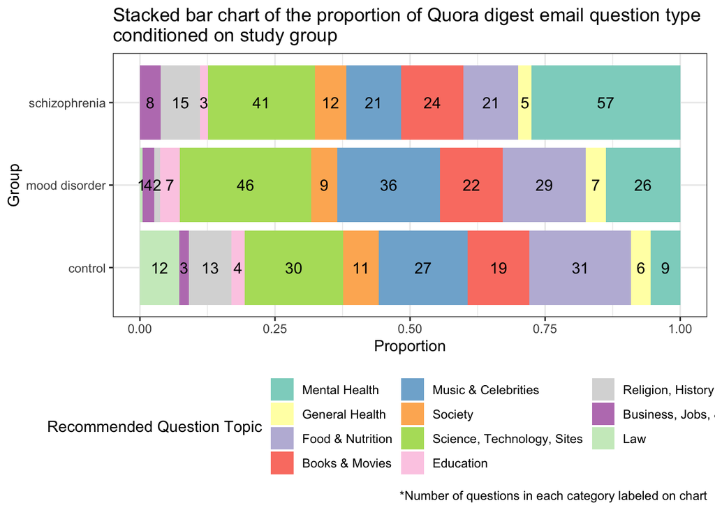

### Word Clouds

#### Control

A word cloud of all nouns and adjectives with at least a frequency of 2 in the Quora Digest emails of the control.

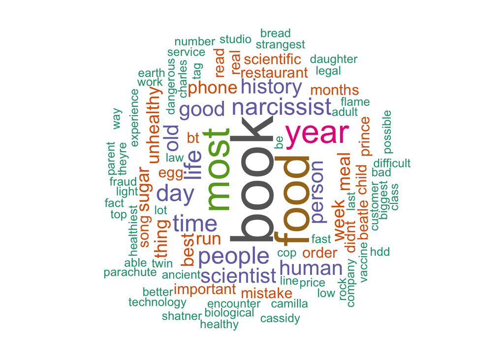

#### Mood Disorder

A word cloud of all nouns and adjectives with at least a frequency of 2 in the Quora Digest emails of the Mood Disorder group.

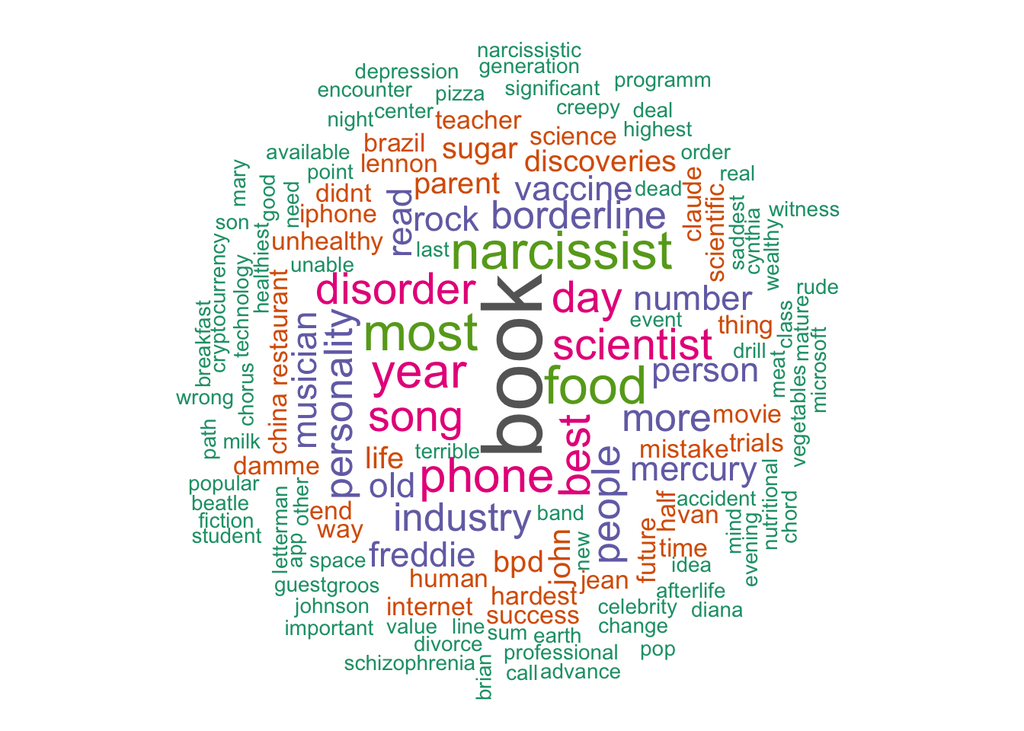

#### Schizophrenia

A word cloud of all nouns and adjectives with at least a frequency of 2 in the Quora Digest emails of the Schizophrenia group.

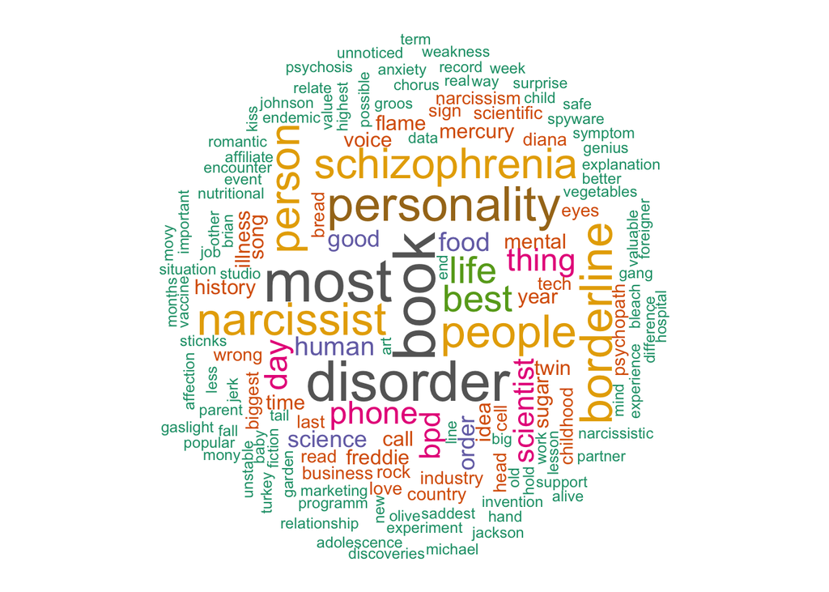

### Frequently Used Nouns and Adjectives

[figure not shown]

## Appendix: All code for this analysis.

```r
knitr::opts_chunk$set(echo = FALSE, collapse = TRUE,
                      warning = FALSE, message = FALSE)
# installing packages
library(readr)
library(dplyr)
library(stringr)
library(tidyverse)
library(lubridate)
library(ggwordcloud)
library(tm)
library(SnowballC)
library(wordcloud)
library(RColorBrewer)
library(tidytext)
library(lubridate)
library(udpipe)
library(textrank)
library(lattice)
library(jcolors)
library(scales)
library(table1)
ud_model <- udpipe_download_model(language = "english")
ud_model <- udpipe_load_model(ud_model$file_model)
set.seed(122)
theme_set(theme_bw())
# Clean data frame
clean <- function(f) {
  df <-
    data.frame(question = str_extract_all(
      read_file(f),
      "To:.*.com|Date:.*\r\n|Question:.*\r*\n*.*\\?"
    )) %>%
    setNames(c("question")) %>%
    mutate(question = str_replace_all(question, "To: |Date: |Question: |\r|\n|=", ""))
  email <- df[1, 1]
  Timestamp <-
    dmy_hms(str_extract(df[3, 1], "[0-9]+.* (?=[\\+0000])"), tz = "America/Los_Angeles")
  date <- date(Timestamp)
  x <-
    cbind(data.frame(email, date), question = df %>% tail(length(df) - 4))
  return(x)
}

# Create word clouds
wordcloudmaker <-
  function(d,
           grp = NA,
           words,
           freq,
           minfreq = 1,
           maxwords = 200,
           scal = c(4, .5)) {
    if (!is.na(grp)) {
      dt <- subset(d, group == grp)
    } else {
      dt <- d
    }
    wordcloud(
      words = dt[[words]],
      freq = dt[[freq]],
      scale = scal,
      min.freq = minfreq,
      max.words = maxwords,
      random.order = FALSE,
      rot.per = 0.35,
      colors = brewer.pal(8, "Dark2")
    )
  }


# Get part of speech specified
commonPOS <- function(df, grp, pos = "NOUN") {
  d <- subset(df, group == grp)
  d[["words"]] <- str_replace_all(d[["words"]], "e2809.", "")
  stats <-
    subset(as.data.frame(udpipe_annotate(ud_model, x = d[["words"]])), upos %in% pos)
  stats <- txt_freq(x = stats$lemma)
  stats$key <- factor(stats$key, levels = rev(stats$key))
  stats
}

# Return p-value for descriptive stats
pvalue <- function(x, ...) {
  # Construct vectors of data y, and groups (strata) g
  y <- unlist(x)
  g <- factor(rep(1:length(x), times = sapply(x, length)))
  if (is.numeric(y)) {
    # For numeric variables, perform a standard 2-sample t-test
    p <- t.test(y ~ g)$p.value
  } else {
    # For categorical variables, perform a chi-squared test of independence
    p <- chisq.test(table(y, g))$p.value
  }
  # Format the p-value, using an HTML entity for the less-than sign.
  # The initial empty string places the output on the line below the variable label.
  c("", sub("<", "&lt;", format.pval(p, digits = 3, eps = 0.001)))
}
filenames <-
  list.files("~/RStudio/Comps/healthcompsdata/emails/", full.names = TRUE)
participants <- data.frame(
  email = c(
    "leea5105@gmail.com",
    "aj8743124@gmail.com",
    "bryantcarol868@yahoo.com",
    "cassidybarnes75@gmail.com",
    "aubreyyates2@gmail.com",
    "blakeg853@gmail.com"
  ),
  group = c(
    "mood disorder",
    "schizophrenia",
    "control",
    "mood disorder",
    "schizophrenia",
    "control"
  )
)

quora_ads <- read.csv("quora_ads.csv", na.strings = c("")) %>%
  pivot_longer(cols = starts_with("ad"),
               names_to = "ad_number",
               values_to = "ad") %>%
  mutate(
    sponsor = str_extract(ad, ".*"),
    words = str_extract_all(str_to_lower(ad),  boundary("word")),
    sponsor_type = case_when(
      sponsor %in% c(
        "BHMD",
        "BHMD Dermal",
        "Eden Health",
        "Gundry MD",
        "System1 | Bladder Cancer",
        "System1 | Multiple Sclerosis",
        "System1 | Spinal Muscular Atrophy"
      ) ~ "Healthcare",
      sponsor %in% c(
        "Atlassian",
        "Avnet",
        "BairesDev",
        "CapitalOne Shopping",
        "ContentFly",
        "Local Solar Power Programs" ,
        "ManageEngine",
        "Network Solutions",
        "Shopify",
        "Square Online",
        "The Motley Fool",
        "TruthFinder",
        "Wesley Financial Group, LLC"
      )  ~ "Selling Product(s)",
      sponsor %in% c("Forge of Empires", "Gazillions", "Worldlifestyle") ~ "Games Apps & Quizzes",
      sponsor %in% c("Stansberry Research") ~ "Political",
      sponsor %in% c(
        "Best Gadget Advice",
        "History Daily",
        "Magellan Times",
        "Maternity Week",
        "The Penny Hoarder",
        "Upbeat News",
        "Worldlifestyle"
      ) ~ "News"
    ),
    date = mdy(time)
  )


df <- lapply(filenames, clean) %>%
  bind_rows() %>%
  inner_join(participants, by = "email") %>%
  mutate(
    question = str_remove_all(question, "E28099|\""),
    topic_breakdown = case_when(
      str_detect(
        str_to_lower(question),
        "disorder|anxiety|mood|bipolar|schizophrenia|bpd|narciss|
        epression|psycho|why are you sad|traumatic event|truly happy|borderline"
      ) ~ "mental health",
      str_detect(
        str_to_lower(question),
        "medicine|vaccine|doctor|physician|vitamin c|hospital|health diagnosis|
        pandemic|blood sugar|push up"
      ) ~ "general health",
      str_detect(
        str_to_lower(question),
        "food|bread|pizza|meat|steak|vegetables|nutrition|nutrient|sugar|milk|
        oysters|pasta|oats|breakfast|honey|meal|suya|tuna|onion|dish|eat less|chefs|salt|egg mcmuffin|pork|fruits"
      ) ~ "food",
      str_detect(
        str_to_lower(question),
        "phone|iphone|technology|tech|computer|c\\+\\+|5g|cryptocurrency|startup|
        microsoft|linux|cell phone|bot|samsung|spyware|phone|chip production|transistor|
        screen recorder|batter|blockchain|dogecoin|electric car|purple bullet|cryptos"
      ) ~ "technology",
      str_detect(
        str_to_lower(question),
        "snapchat|twitter|facebook|instagram|discord|youtube"
      ) ~ "social media",
      str_detect(
        str_to_lower(question),
        "scientific|science|scientist|drilling|discoveries|periodic table|einstein|
        inventions|atom|giant egg discovered|oldest living things|bleach|could i survive|electrons"
      ) ~ "science",
      str_detect(
        str_to_lower(question),
        "music|k-pop|rock star|hard rock|song|bts|studio|rock and roll|rock band|
        rock|paul mccartney|freddie mercury|john lennon|mick jagger|david crosby|billy|
        beatles|peter gabriel|bobby mcgee|brian may|composer|michael jackson|singer|heavy metal|good artist"
      ) ~ "music",
      str_detect(str_to_lower(question), "book|read|stephen king") ~ "books",
      str_detect(
        str_to_lower(question),
        "movie|lord of the rings|mcu scene|marvel cinematic universe|oscar win"
      ) ~ "movie",
      str_detect(str_to_lower(question), "sum of") ~ "math",
      str_detect(
        str_to_lower(question),
        "celebrity|john wayne|prince charles|tom cruise|william shatner|princess diana"
      ) ~ "celebrity",
      str_detect(
        str_to_lower(question),
        "business|job|employee|switch to product based|market|your boss|good career"
      ) ~ "business/marketing/jobs",
      str_detect(
        str_to_lower(question),
        "history|henry viii|roswell|challenger astronauts|person of all time|
        chemical reaction|50s and 60s|jimmy stewar|a human has survived"
      ) ~ "history",
      str_detect(
        str_to_lower(question),
        "teacher|phd|graduate|school|student|educat|community college"
      ) ~ "education",
      str_detect(
        str_to_lower(question),
        "my son|parent|daughter|family|kids|child|12 year old"
      ) ~ "family/children",
      str_detect(
        str_to_lower(question),
        "religion|bible|eckhart tolle|demon|angels|lucifer effect"
      ) ~ "religion",
      str_detect(str_to_lower(question), "puppy|dog|cat|pigeon") ~ "animal",
      str_detect(
        str_to_lower(question),
        "it correct to say between|bad handwriting"
      ) ~ "grammar",
      str_detect(str_to_lower(question), "money|financ|wealth") ~ "finance",
      str_detect(str_to_lower(question), "british|usa|uk|country|turkey") ~ "culture/country",
      str_detect(
        str_to_lower(question),
        "military|ar-15|gun|law|cops|legal|police officer|property line|horrific crime "
      ) ~ "law",
      str_detect(
        str_to_lower(question),
        "mature|romantic|compromising|inappropriate|ruined your life|
        experience you had|etiquette points|spanking|walked into your home|
        insane thing|dangerous person|embarrassing moment|trusted your gut|
        found the one|made you feel sorry|secret life|wedding guest|parked car"
      ) ~ "other social"
    ),
    topic = fct_relevel(
      case_when(
        topic_breakdown == "mental health" ~ "Mental Health",
        topic_breakdown == "general health" ~ "General Health",
        topic_breakdown == "food" ~ "Food & Nutrition",
        topic_breakdown == "law" ~ "Law",
        topic_breakdown %in% c("science", "technology", "social media") ~ "Science, Technology, Sites",
        topic_breakdown %in% c("books", "movie") ~ "Books & Movies",
        topic_breakdown %in% c("music", "celebrity") ~ "Music & Celebrities",
        topic_breakdown %in% c("math", "education", "grammar") ~ "Education",
        topic_breakdown %in% c("family/children", "other social", "animal") ~ "Society",
        topic_breakdown %in% c("finance", "business/marketing/jobs") ~ "Business, Jobs, & Finance",
        topic_breakdown %in% c("history", "religion", "culture/country") ~ "Religion, History, & Culture",
        TRUE ~ topic_breakdown
      ),
      "Mental Health",
      "General Health",
      "Food & Nutrition",
      "Books & Movies",
      "Music & Celebrities",
      "Society",
      "Science, Technology, Sites",
      "Education",
      "Religion, History, & Culture",
      "Business, Jobs, & Finance",
      "Law"
    )
  )
```

```r
write.csv(participants, file = "participants.csv")
write.csv(df, file = "quora_digest_out.csv")

q <- quora_ads %>% select(-words)
write.csv(as.data.frame(q), file = "quora_ads_out.csv")
quora_ads.rmna <- quora_ads %>%
  filter(!is.na(sponsor_type)) %>%
  mutate(
    sponsor = case_when(
      str_detect(sponsor, "BHMD") ~ "Beverly Hills MD (BHMD)",
      str_detect(sponsor, "System1") ~ "System1",
      TRUE ~ sponsor
    )
  )

label(quora_ads.rmna$sponsor_type) <- "Quora Site Ad Type"
label(quora_ads.rmna$sponsor) <- "Quora Site Ad Sponsors"


table1(
  ~ sponsor_type + sponsor |
    group,
  data = quora_ads.rmna,
  overall = F,
  extra.col = list(`P-value` = pvalue)
)
quora_ads %>%
  filter(!is.na(sponsor_type)) %>%
  group_by(group, sponsor_type) %>%
  summarize(n = n()) %>%
  ungroup() %>%
  ggplot(aes(
    fill = sponsor_type,
    y = n,
    x = group,
    label = n
  )) +
  geom_bar(position = "fill", stat = "identity") +
  coord_flip() +
  labs(x = "Group",
       y = "Proportion",
       fill = "Advertisement Category",
       title =str_wrap("Stacked bar chart of the proportion of each Quora advertisement type conditioned on study",75),
       caption = "*Number of questions in each category labeled on chart") +
  theme(legend.position = "bottom") +
  geom_text(position = position_fill(vjust = 0.5)) +
  scale_fill_brewer(palette = "Set3") +
  guides(fill = guide_legend(ncol = 2))


ggsave("quora_ads_bar.png", width = 10, height = 7, units = "in")
label(df$topic) <- "Quora Digest Question Topic"
table1(
  ~ topic |
    group,
  data = df,
  overall = F,
  extra.col = list(`P-value` = pvalue)
)
digest <- df %>%
  mutate(words = str_extract_all(str_to_lower(question),  boundary("word"))) %>%
  unnest(cols = c(words)) %>%
  mutate(words_rmstop = ifelse(
    words %in% stopwords("english") |
      removeNumbers(words) == "",
    NA,
    as.character(words)
  ))

df %>%
  group_by(group, topic) %>%
  summarize(n = n()) %>%
  ungroup() %>%
  ggplot(aes(
    fill = topic,
    y = n,
    x = group,
    label = n
  )) +
  geom_bar(position = "fill", stat = "identity") +
  coord_flip() +
  labs(x = "Group",
       y = "Proportion",
       title = str_wrap("Stacked bar chart of the proportion of Quora digest email question type conditioned on study group", 75),
       fill = "Recommended Question Topic",
       caption = "*Number of questions in each category labeled on chart") +
  theme(legend.position = "bottom") +
  geom_text(position = position_fill(vjust = 0.5))  +
  scale_fill_brewer(palette = "Set3") +
  guides(fill = guide_legend(ncol = 3))

ggsave("quora_digest_bar.png", width = 11, height = 7, units = "in")
wordcloudmaker(
  d = commonPOS(digest, "control", c("NOUN", "ADJ")),
  words = "key",
  freq = "freq",
  scal = c(5, .5),
  minfreq = 2
)
wordcloudmaker(
  d = commonPOS(digest, "mood disorder", c("NOUN", "ADJ")),
  words = "key",
  freq = "freq",
  scal = c(3.5, .5),
  minfreq = 2
)
wordcloudmaker(
  d = commonPOS(digest, "schizophrenia", c("NOUN", "ADJ")),
  words = "key",
  freq = "freq",
  scal = c(3, .5),
  minfreq = 2
)
complete_df <- commonPOS(digest, "control", c("NOUN", "ADJ")) %>%
  full_join(commonPOS(digest, "mood disorder", c("NOUN", "ADJ")), by = "key") %>%
  full_join(commonPOS(digest, "schizophrenia", c("NOUN", "ADJ")), by = "key") %>%
  rename(
    freq.control = freq.x,
    freq.md = freq.y,
    freq.schiz = freq,
    freq_pct.control = freq_pct.x,
    freq_pct.md = freq_pct.y,
    freq_pct.schiz = freq_pct,
  ) %>%
  filter(freq.control > 4 | freq.md > 4 | freq.schiz > 4) %>%
  arrange(desc(freq.control), desc(freq.md), desc(freq.schiz)) %>%
  pivot_longer(cols = starts_with("freq."),
               names_to = "group",
               values_to = "freq")


complete_df %>%
  group_by(key) %>%
  mutate(total = sum(freq),
         group = factor(case_when(group == "freq.md" ~ "Mood Disorder",
                           group == "freq.schiz" ~ "Schizophrenia",
                           group == "freq.control" ~ "Control"))) %>%
  ggplot(aes(x = reorder(key, total), y = freq, fill = group))+
  geom_bar(stat="identity") +
  coord_flip() +
  facet_grid(~group) +
  labs(x = "Nouns and Adjectives",
       y = "Frequency",
       fill = "Group",
       title = str_wrap("Frequency of nouns and adjectives used in Quora Digest emails by study group.",65),
       caption = "*Only nouns and adjectives with a frequency of at least 4 in one study group are shown.")

ggsave("nounadj.png")
```

# References

Birnbaum, Michael L., Raquel Norel, Anna Van Meter, Asra F. Ali, Elizabeth Arenare, Elif Eyigoz, Carla Agurto, Nicole Germano, John M. Kane, and Guillermo A. Cecchi. “Identifying Signals Associated with Psychiatric Illness Utilizing Language and Images Posted to Facebook.” *Npj Schizophrenia* 6, no. 1 (December 2020): 38. https://doi.org/10.1038/s41537-020-00125-0.

Conell, Jörn, Rita Bauer, Tasha Glenn, Martin Alda, Raffaella Ardau, Bernhard T. Baune, Michael Berk, et al. “Online Information Seeking by Patients with Bipolar Disorder: Results from an International Multisite Survey.” *International Journal of Bipolar Disorders* 4, no. 1 (December 2016): 17. https://doi.org/10.1186/s40345-016-0058-0.

Eichstaedt, Johannes C., Robert J. Smith, Raina M. Merchant, Lyle H. Ungar, Patrick Crutchley, Daniel Preoţiuc-Pietro, David A. Asch, and H. Andrew Schwartz. “Facebook Language Predicts Depression in Medical Records.” *Proceedings of the National Academy of Sciences* 115, no. 44 (October 30, 2018): 11203–8. https://doi.org/10.1073/pnas.1802331115.

“Facebook Posts Help Detect Psychiatric Illness, Study Finds.” Accessed May 12, 2021. https://nypost.com/2020/12/06/facebook-posts-help-detect-psychiatric-illness-study-finds/.

Futurity. “Facebook Posts with These Words Can Predict Depression,” October 22, 2018. https://www.futurity.org/depression-facebook-prediction-1893812/.

“How Facebook Can Be Used to Predict a Manic Episode.” Accessed January 13, 2021. https://www.vice.com/en/article/kbznv9/how-facebook-can-be-used-to-predict-a-manic-episode.

“Inside Facebook’s Suicide Algorithm.” Accessed May 12, 2021. https://www.businessinsider.com/facebook-is-using-ai-to-try-to-predict-if-youre-suicidal-2018-12.

Money and Mental Health Policy Institute. “Is Facebook Tipping-off Advertisers about Your Mental Health?,” May 3, 2017. https://www.moneyandmentalhealth.org/facebook-mental-health/.

Khazan, Olga. “What Your Facebook Posts Say About Your Mental Health.” The Atlantic, November 6, 2019. https://www.theatlantic.com/health/archive/2019/11/what-your-tweets-say-about-your-mood/601510/.

Schrank, Beate, Ingrid Sibitz, Annemarie Unger, and Michaela Amering. “How Patients with Schizophrenia Use the Internet: Qualitative Study.” *Journal of Medical Internet Research* 12, no. 5 (December 19, 2010): e70. https://doi.org/10.2196/jmir.1550.

Uprichard, Lucy. “The Suicide Algorithm: Facebook’s Self-Appointed Role in Mental Health.” *The Technoskeptic* (blog), June 28, 2017. https://thetechnoskeptic.com/suicide-algorithm-facebook-mental-health/.

“When Facebook and Instagram Think You’re Depressed.” Accessed May 12, 2021. https://www.vice.com/en/article/pg7d59/when-facebook-and-instagram-thinks-youre-depressed.